# particle_placement_analysis.R

Lauren Shin

Wed Dec 13 11:33:31 2017

# Introduction

Data: particleplacement_icegb.csv  
Information from 104_datafiles.pdf about variables:  
**CONSTRUCTION**: the dependent variable, the choice of construction with a phrasal verb:  
___ **V_PRT_DO** (e.g., He picked the dirt up) vs. **V_DO_PRT** (e.g., He picked it up)  
**MODE**: the medium in which the construction was used: spoken vs. written  
**REGISTER**: the register in which the construction was used:  
___ monolog vs. dialog vs. mix vs. printed vs. nonprinted  
**SUBREGISTER**: the subregister in which the construction was used  
**PARTICLE**: the particle of the transitive phrasal verb  
**TYPE**: the type of DO: a.other vs. b.lexical vs. c.pronoun vs. d.quantifier  
**LENGTH**: the length of the DO in words  
Question: which independent variables, if any, influence the dependent variable’s value?

```r
################################################################################
# how to get y labels of horizantal bar graphs to display closer to graph/
# and not get cut off?
# V_PRT_DO v V_DO_PRT -- what do those signify?  Particle and direct object?
# example is unclear

rm(list=ls(all=TRUE)) # clear memory

# sets the working directory, works locally
# might have to change it for other machines
setwd("~/LING 104/particle placement 2")

summary(x <- read.delim("particleplacement_icegb.csv"))
```

```
##  MODE           REGISTER        SUBREGISTER     PARTICLE     CONSTRUCTION
##  S:1587   dialog    :921   private    :543   up     :578   V_DO_PRT:1192
##  W: 734   mix       : 98   unscripted :480   out    :490   V_PRT_DO:1129
##           monolog   :568   public     :378   in     :229
##           nonprinted:172   nonacademic:143   off    :177
##           printed   :562   creative   :142   down   :176
##                            letters    :131   on     :157
##                            (Other)    :504   (Other):514
##         TYPE          LENGTH
##  a.other  :   7   Min.   : 1.00
##  b.lex    :1525   1st Qu.: 1.00
##  c.pronoun: 777   Median : 2.00
##  d.quant  :  12   Mean   : 3.23
##                   3rd Qu.: 3.00
##                   Max.   :61.00
##
```

# Data Exploration

```r
# for visibility
colors <- c("dark blue", "dark green", "red")
```

## Mode

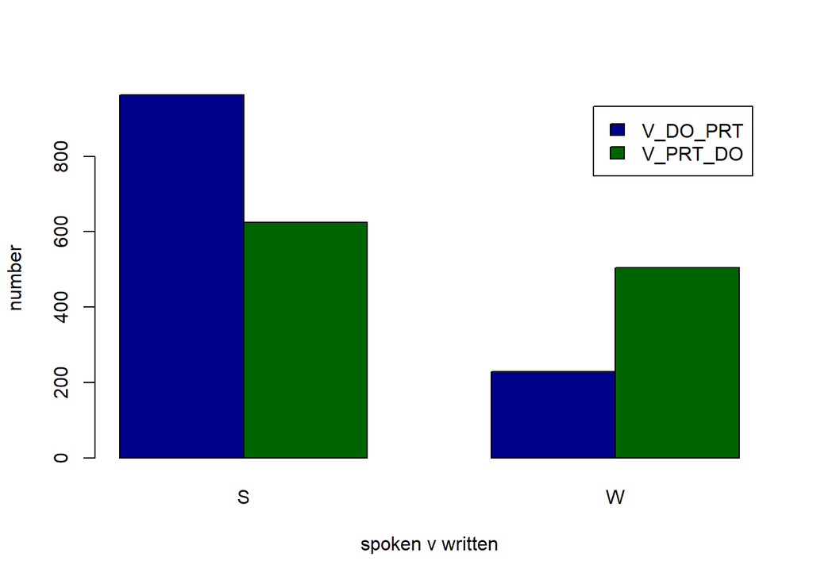

```r
barplot(table(x$CONSTRUCTION, x$MODE),
        ylab = "number",
        xlab = "spoken v written",
        beside = TRUE,
        legend = TRUE,
        col = colors[1:2])
```

```r
# shows that there is a big difference between mode type and construction
# spoken mode tends to have more V_DO_PRT, while written has more V_PRT_DO
# there are also fewer datapoints for the written mode
```

## Register

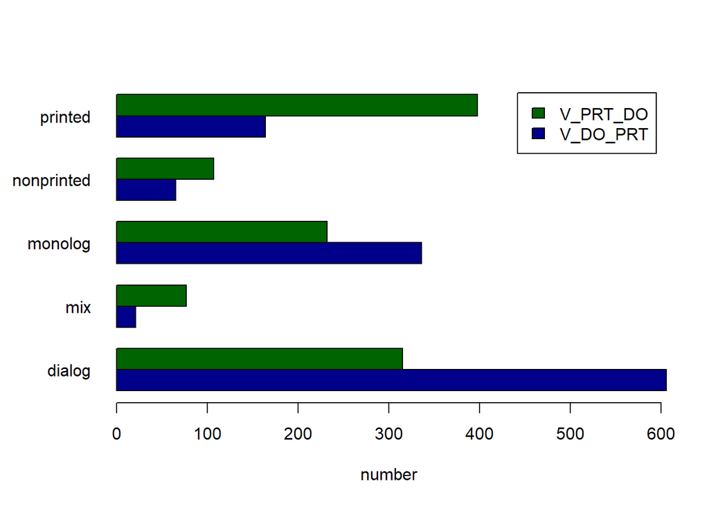

```r
# barplot looks fine with adjusted margins
# default par(mar=c(5.1, 4.1, 4.1, 2.1))
# bottom, left, top, right

par(mar=c(5.1, 5.5, 4.1, 2.1))

barplot(table(x$CONSTRUCTION, x$REGISTER),
        xlab = "number",
        beside = TRUE,
        legend = TRUE,
        horiz = TRUE,
        las = 1,
        col = colors[1:2])
```

## Subregister

```r
table(x$SUBREGISTER, x$CONSTRUCTION)
```

```
##
##                   V_DO_PRT V_PRT_DO
##   academic               8       56
##   broadcast             21       77
##   creative              72       70
##   instructional         30       56
##   letters               57       74
##   nonacademic           24      119
##   nonprofessional        8       33
##   persuasive            10       23
##   private              418      125
##   public               188      190
##   reportage             20       74
##   scripted              31       57
##   unscripted           305      175
```

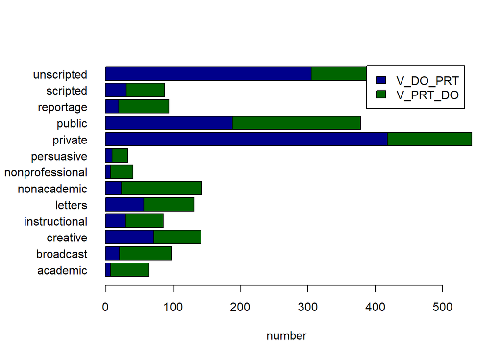

```r
# lots of variance in numbers, hard to see an overall trend

# readjusting margins to fit all labels on
par(mar=c(5.1, 7.1, 4.1, 2.1))

barplot(table(x$CONSTRUCTION, x$SUBREGISTER),
        horiz = TRUE,
        las = 1,
        xlab = "number",
        legend = TRUE,
        args.legend = "bottomleft",
        col = colors[1:2])
```

```r
# there are a few really high spikes which is slightly concerning
# generally, smaller bars are dominated by green (V_PRT_DO)
# while larger are dominated by blue (V_DO_PRT)
```

## Particle

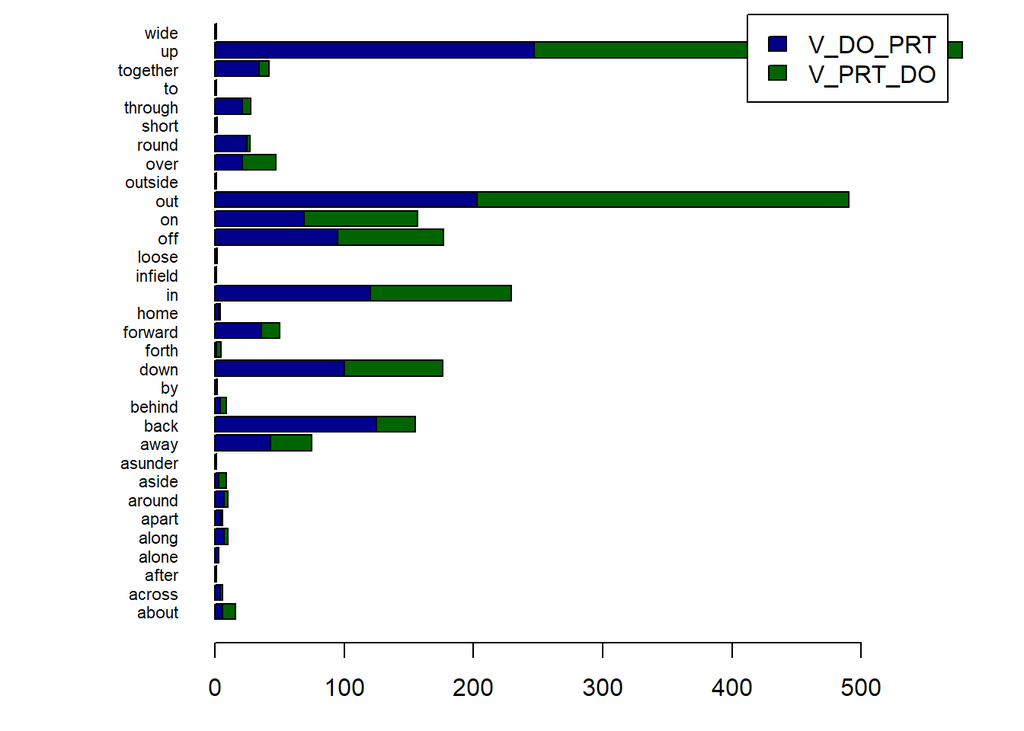

```r
# adjusting margin again to fit all labels
par(mar=c(3, 7.1, 0, 2.1))

barplot(table(x$CONSTRUCTION, x$PARTICLE),
        horiz = TRUE,
        cex.names = .7,
        las = 1,
        legend = TRUE,
        col = colors[1:2])
```

```r
# kind of difficult to see, but
# there is a huge variance in number of data points for each particle
# overall, bars look to be split fairly evenly though
```

## Type

```r
table(x$TYPE, x$CONSTRUCTION)
```

```
##
##             V_DO_PRT V_PRT_DO
##   a.other          4        3
##   b.lex          428     1097
##   c.pronoun      758       19
##   d.quant          2       10
```

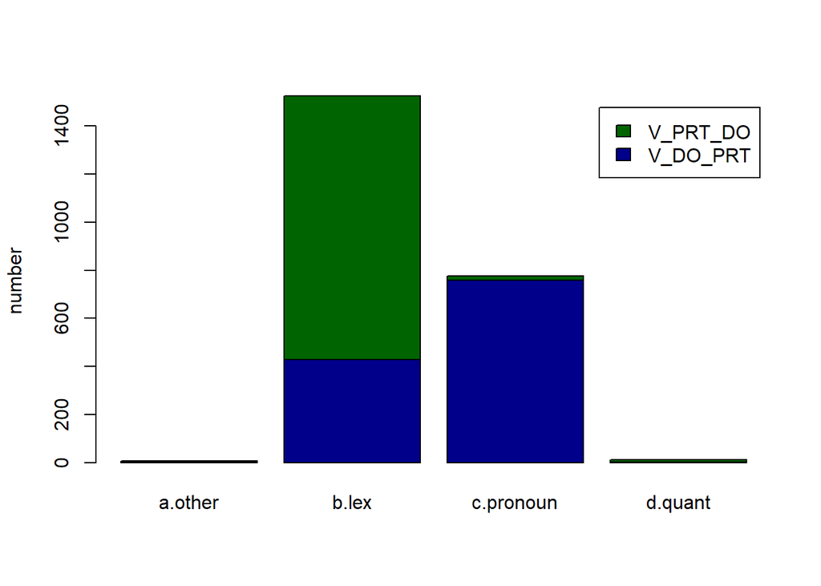

```r
# very big variance in numbers here; 2 to 1097
# overall, numbers are not split evenly within rows

# again, needs different formatting to see what's going on
barplot(table(x$CONSTRUCTION, x$TYPE),
        ylab = "number",
        legend = TRUE,
        col = colors[1:2])
```

```r
# doesn't really help...
# need some other thing to help visualize
```